# Documentos reproducibles con R

Programación y manejo de datos con R (Slides 07)

Pedro J. Pérez

pedro.j.perez@uv.es

## Tidyverse workflow e investigación reproducible

- La última etapa de un análisis es … comunicar

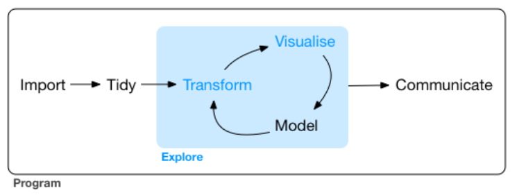

- Realizaremos **todas las etapas con R**, sin cambiar de programa. Para ello usaremos **Rmarkdown**

## ¿Qué es Rmarkdown?

- Podemos pensar que es **una forma de escribir** nuestros informes/análisis directamente desde R. No nos hará falta salir de R; todo se hace en R, desde los cálculos estadísticos, los gráficos, el texto o narrativa y la maquetación.

Ventaja principal

- Nuestros informes serán **reproducibles**. Puede ver [este video](https://www.youtube.com/watch?v=s3JldKoA0zw) o leer [este post](https://rfortherestofus.com/2019/03/r-killer-feature-rmarkdown/)
- Además, con Rmd se pueden generar multitud de outputs. Por ejemplo, visita [está galería](https://rmarkdown.rstudio.com/gallery.html) o [este listado](https://rmarkdown.rstudio.com/formats.html)

¿De verdad necesito conocer Rmarkdown?

- **SÍ!!** Puede [transformar tu forma de trabajar](https://rfortherestofus.com/2019/03/r-killer-feature-rmarkdown/)
- Todos tenemos que hacer documentos con algún contenido estadístico: informes o transparencias o …. **`Rmarkdown`** hace posible que podamos hacer esos documentos **directamente desde R**. Además, nuestros informes serán [Reproducibles!!](https://www.youtube.com/watch?v=s3JldKoA0zw)

## ¿Le damos una oportunidad a **R**markdown? 🤔 ok, vale!!!

PERO … !!!

- Resulta que **en julio de 2022 apareció Quarto**, la segunda generación de Rmarkdown … así que …

bye-bye Rmarkdown (Rmd)

Bienvenido Quarto (Qmd)!!!